# Risk Factor Analysis

## Outcome Variable

**Outcome Variable:** ever_swasted

## Predictor Variables

**Intervention Variable:** birthwt

**Adjustment Set:**

- arm
- sex
- W_mage
- meducyrs
- feducyrs
- vagbrth
- single
- brthmon
- W_parity
- delta_W_mage
- delta_meducyrs
- delta_feducyrs
- delta_vagbrth
- delta_single
- delta_brthmon
- delta_W_parity

## Stratifying Variables

The analysis was stratified on these variable(s):

- agecat
- studyid
- country

## Data Summary

| agecat | studyid | country | birthwt | ever_swasted | n_cell | n |
| --- | --- | --- | --- | --- | --- | --- |
| 0-24 months (no birth wast) | CMC-V-BCS-2002 | INDIA | Normal or high birthweight | 0 | 271 | 361 |
| 0-24 months (no birth wast) | CMC-V-BCS-2002 | INDIA | Normal or high birthweight | 1 | 50 | 361 |
| 0-24 months (no birth wast) | CMC-V-BCS-2002 | INDIA | Low birthweight | 0 | 35 | 361 |
| 0-24 months (no birth wast) | CMC-V-BCS-2002 | INDIA | Low birthweight | 1 | 5 | 361 |
| 0-24 months (no birth wast) | CMIN | BANGLADESH | Normal or high birthweight | 0 | 13 | 17 |
| 0-24 months (no birth wast) | CMIN | BANGLADESH | Normal or high birthweight | 1 | 0 | 17 |
| 0-24 months (no birth wast) | CMIN | BANGLADESH | Low birthweight | 0 | 4 | 17 |
| 0-24 months (no birth wast) | CMIN | BANGLADESH | Low birthweight | 1 | 0 | 17 |
| 0-24 months (no birth wast) | COHORTS | GUATEMALA | Normal or high birthweight | 0 | 825 | 917 |
| 0-24 months (no birth wast) | COHORTS | GUATEMALA | Normal or high birthweight | 1 | 13 | 917 |
| 0-24 months (no birth wast) | COHORTS | GUATEMALA | Low birthweight | 0 | 74 | 917 |
| 0-24 months (no birth wast) | COHORTS | GUATEMALA | Low birthweight | 1 | 5 | 917 |
| 0-24 months (no birth wast) | COHORTS | INDIA | Normal or high birthweight | 0 | 5070 | 6524 |
| 0-24 months (no birth wast) | COHORTS | INDIA | Normal or high birthweight | 1 | 243 | 6524 |
| 0-24 months (no birth wast) | COHORTS | INDIA | Low birthweight | 0 | 1124 | 6524 |
| 0-24 months (no birth wast) | COHORTS | INDIA | Low birthweight | 1 | 87 | 6524 |
| 0-24 months (no birth wast) | COHORTS | PHILIPPINES | Normal or high birthweight | 0 | 2494 | 2975 |
| 0-24 months (no birth wast) | COHORTS | PHILIPPINES | Normal or high birthweight | 1 | 210 | 2975 |
| 0-24 months (no birth wast) | COHORTS | PHILIPPINES | Low birthweight | 0 | 233 | 2975 |
| 0-24 months (no birth wast) | COHORTS | PHILIPPINES | Low birthweight | 1 | 38 | 2975 |
| 0-24 months (no birth wast) | CONTENT | PERU | Normal or high birthweight | 0 | 2 | 2 |
| 0-24 months (no birth wast) | CONTENT | PERU | Normal or high birthweight | 1 | 0 | 2 |
| 0-24 months (no birth wast) | CONTENT | PERU | Low birthweight | 0 | 0 | 2 |
| 0-24 months (no birth wast) | CONTENT | PERU | Low birthweight | 1 | 0 | 2 |
| 0-24 months (no birth wast) | EE | PAKISTAN | Normal or high birthweight | 0 | 203 | 376 |
| 0-24 months (no birth wast) | EE | PAKISTAN | Normal or high birthweight | 1 | 40 | 376 |
| 0-24 months (no birth wast) | EE | PAKISTAN | Low birthweight | 0 | 107 | 376 |
| 0-24 months (no birth wast) | EE | PAKISTAN | Low birthweight | 1 | 26 | 376 |
| 0-24 months (no birth wast) | GMS-Nepal | NEPAL | Normal or high birthweight | 0 | 380 | 659 |
| 0-24 months (no birth wast) | GMS-Nepal | NEPAL | Normal or high birthweight | 1 | 89 | 659 |

[output cut: 294 more lines]

The following strata were considered:

- agecat: 0-24 months (no birth wast), studyid: CMC-V-BCS-2002, country: INDIA
- agecat: 0-24 months (no birth wast), studyid: CMIN, country: BANGLADESH
- agecat: 0-24 months (no birth wast), studyid: COHORTS, country: GUATEMALA
- agecat: 0-24 months (no birth wast), studyid: COHORTS, country: INDIA
- agecat: 0-24 months (no birth wast), studyid: COHORTS, country: PHILIPPINES
- agecat: 0-24 months (no birth wast), studyid: CONTENT, country: PERU
- agecat: 0-24 months (no birth wast), studyid: EE, country: PAKISTAN
- agecat: 0-24 months (no birth wast), studyid: GMS-Nepal, country: NEPAL
- agecat: 0-24 months (no birth wast), studyid: IRC, country: INDIA
- agecat: 0-24 months (no birth wast), studyid: JiVitA-3, country: BANGLADESH
- agecat: 0-24 months (no birth wast), studyid: JiVitA-4, country: BANGLADESH
- agecat: 0-24 months (no birth wast), studyid: Keneba, country: GAMBIA
- agecat: 0-24 months (no birth wast), studyid: MAL-ED, country: BANGLADESH
- agecat: 0-24 months (no birth wast), studyid: MAL-ED, country: BRAZIL
- agecat: 0-24 months (no birth wast), studyid: MAL-ED, country: INDIA
- agecat: 0-24 months (no birth wast), studyid: MAL-ED, country: NEPAL
- agecat: 0-24 months (no birth wast), studyid: MAL-ED, country: PERU
- agecat: 0-24 months (no birth wast), studyid: MAL-ED, country: SOUTH AFRICA
- agecat: 0-24 months (no birth wast), studyid: MAL-ED, country: TANZANIA, UNITED REPUBLIC OF
- agecat: 0-24 months (no birth wast), studyid: NIH-Birth, country: BANGLADESH
- agecat: 0-24 months (no birth wast), studyid: NIH-Crypto, country: BANGLADESH
- agecat: 0-24 months (no birth wast), studyid: PROBIT, country: BELARUS
- agecat: 0-24 months (no birth wast), studyid: PROVIDE, country: BANGLADESH
- agecat: 0-24 months (no birth wast), studyid: ResPak, country: PAKISTAN
- agecat: 0-24 months (no birth wast), studyid: SAS-CompFeed, country: INDIA
- agecat: 0-24 months (no birth wast), studyid: TanzaniaChild2, country: TANZANIA, UNITED REPUBLIC OF
- agecat: 0-24 months (no birth wast), studyid: ZVITAMBO, country: ZIMBABWE
- agecat: 0-6 months (no birth wast), studyid: CMC-V-BCS-2002, country: INDIA
- agecat: 0-6 months (no birth wast), studyid: CMIN, country: BANGLADESH
- agecat: 0-6 months (no birth wast), studyid: COHORTS, country: GUATEMALA
- agecat: 0-6 months (no birth wast), studyid: COHORTS, country: INDIA
- agecat: 0-6 months (no birth wast), studyid: COHORTS, country: PHILIPPINES
- agecat: 0-6 months (no birth wast), studyid: CONTENT, country: PERU
- agecat: 0-6 months (no birth wast), studyid: EE, country: PAKISTAN
- agecat: 0-6 months (no birth wast), studyid: GMS-Nepal, country: NEPAL
- agecat: 0-6 months (no birth wast), studyid: IRC, country: INDIA
- agecat: 0-6 months (no birth wast), studyid: JiVitA-3, country: BANGLADESH
- agecat: 0-6 months (no birth wast), studyid: JiVitA-4, country: BANGLADESH
- agecat: 0-6 months (no birth wast), studyid: Keneba, country: GAMBIA
- agecat: 0-6 months (no birth wast), studyid: MAL-ED, country: BANGLADESH
- agecat: 0-6 months (no birth wast), studyid: MAL-ED, country: BRAZIL
- agecat: 0-6 months (no birth wast), studyid: MAL-ED, country: INDIA
- agecat: 0-6 months (no birth wast), studyid: MAL-ED, country: NEPAL
- agecat: 0-6 months (no birth wast), studyid: MAL-ED, country: PERU
- agecat: 0-6 months (no birth wast), studyid: MAL-ED, country: SOUTH AFRICA
- agecat: 0-6 months (no birth wast), studyid: MAL-ED, country: TANZANIA, UNITED REPUBLIC OF
- agecat: 0-6 months (no birth wast), studyid: NIH-Birth, country: BANGLADESH
- agecat: 0-6 months (no birth wast), studyid: NIH-Crypto, country: BANGLADESH
- agecat: 0-6 months (no birth wast), studyid: PROBIT, country: BELARUS
- agecat: 0-6 months (no birth wast), studyid: PROVIDE, country: BANGLADESH
- agecat: 0-6 months (no birth wast), studyid: ResPak, country: PAKISTAN
- agecat: 0-6 months (no birth wast), studyid: SAS-CompFeed, country: INDIA
- agecat: 0-6 months (no birth wast), studyid: TanzaniaChild2, country: TANZANIA, UNITED REPUBLIC OF
- agecat: 0-6 months (no birth wast), studyid: ZVITAMBO, country: ZIMBABWE
- agecat: 6-24 months, studyid: CMC-V-BCS-2002, country: INDIA
- agecat: 6-24 months, studyid: CMIN, country: BANGLADESH
- agecat: 6-24 months, studyid: COHORTS, country: GUATEMALA
- agecat: 6-24 months, studyid: COHORTS, country: INDIA
- agecat: 6-24 months, studyid: COHORTS, country: PHILIPPINES
- agecat: 6-24 months, studyid: CONTENT, country: PERU
- agecat: 6-24 months, studyid: EE, country: PAKISTAN
- agecat: 6-24 months, studyid: GMS-Nepal, country: NEPAL
- agecat: 6-24 months, studyid: IRC, country: INDIA
- agecat: 6-24 months, studyid: JiVitA-3, country: BANGLADESH
- agecat: 6-24 months, studyid: JiVitA-4, country: BANGLADESH
- agecat: 6-24 months, studyid: Keneba, country: GAMBIA
- agecat: 6-24 months, studyid: MAL-ED, country: BANGLADESH
- agecat: 6-24 months, studyid: MAL-ED, country: BRAZIL
- agecat: 6-24 months, studyid: MAL-ED, country: INDIA
- agecat: 6-24 months, studyid: MAL-ED, country: NEPAL
- agecat: 6-24 months, studyid: MAL-ED, country: PERU
- agecat: 6-24 months, studyid: MAL-ED, country: SOUTH AFRICA
- agecat: 6-24 months, studyid: MAL-ED, country: TANZANIA, UNITED REPUBLIC OF
- agecat: 6-24 months, studyid: NIH-Birth, country: BANGLADESH
- agecat: 6-24 months, studyid: NIH-Crypto, country: BANGLADESH
- agecat: 6-24 months, studyid: PROBIT, country: BELARUS
- agecat: 6-24 months, studyid: PROVIDE, country: BANGLADESH
- agecat: 6-24 months, studyid: ResPak, country: PAKISTAN
- agecat: 6-24 months, studyid: SAS-CompFeed, country: INDIA
- agecat: 6-24 months, studyid: TanzaniaChild2, country: TANZANIA, UNITED REPUBLIC OF
- agecat: 6-24 months, studyid: ZVITAMBO, country: ZIMBABWE

### Dropped Strata

Some strata were dropped due to rare outcomes:

- agecat: 0-24 months (no birth wast), studyid: CMIN, country: BANGLADESH
- agecat: 0-24 months (no birth wast), studyid: CONTENT, country: PERU
- agecat: 0-24 months (no birth wast), studyid: MAL-ED, country: BANGLADESH
- agecat: 0-24 months (no birth wast), studyid: MAL-ED, country: BRAZIL
- agecat: 0-24 months (no birth wast), studyid: MAL-ED, country: INDIA
- agecat: 0-24 months (no birth wast), studyid: MAL-ED, country: NEPAL
- agecat: 0-24 months (no birth wast), studyid: MAL-ED, country: PERU
- agecat: 0-24 months (no birth wast), studyid: MAL-ED, country: SOUTH AFRICA
- agecat: 0-24 months (no birth wast), studyid: MAL-ED, country: TANZANIA, UNITED REPUBLIC OF
- agecat: 0-24 months (no birth wast), studyid: PROBIT, country: BELARUS
- agecat: 0-24 months (no birth wast), studyid: ResPak, country: PAKISTAN
- agecat: 0-6 months (no birth wast), studyid: CMC-V-BCS-2002, country: INDIA
- agecat: 0-6 months (no birth wast), studyid: CMIN, country: BANGLADESH
- agecat: 0-6 months (no birth wast), studyid: COHORTS, country: GUATEMALA
- agecat: 0-6 months (no birth wast), studyid: CONTENT, country: PERU
- agecat: 0-6 months (no birth wast), studyid: MAL-ED, country: BANGLADESH
- agecat: 0-6 months (no birth wast), studyid: MAL-ED, country: BRAZIL
- agecat: 0-6 months (no birth wast), studyid: MAL-ED, country: INDIA
- agecat: 0-6 months (no birth wast), studyid: MAL-ED, country: NEPAL
- agecat: 0-6 months (no birth wast), studyid: MAL-ED, country: PERU
- agecat: 0-6 months (no birth wast), studyid: MAL-ED, country: SOUTH AFRICA
- agecat: 0-6 months (no birth wast), studyid: MAL-ED, country: TANZANIA, UNITED REPUBLIC OF
- agecat: 0-6 months (no birth wast), studyid: NIH-Birth, country: BANGLADESH
- agecat: 0-6 months (no birth wast), studyid: NIH-Crypto, country: BANGLADESH
- agecat: 0-6 months (no birth wast), studyid: PROBIT, country: BELARUS
- agecat: 0-6 months (no birth wast), studyid: PROVIDE, country: BANGLADESH
- agecat: 0-6 months (no birth wast), studyid: ResPak, country: PAKISTAN
- agecat: 0-6 months (no birth wast), studyid: TanzaniaChild2, country: TANZANIA, UNITED REPUBLIC OF
- agecat: 6-24 months, studyid: CMIN, country: BANGLADESH
- agecat: 6-24 months, studyid: CONTENT, country: PERU
- agecat: 6-24 months, studyid: MAL-ED, country: BANGLADESH
- agecat: 6-24 months, studyid: MAL-ED, country: BRAZIL
- agecat: 6-24 months, studyid: MAL-ED, country: INDIA
- agecat: 6-24 months, studyid: MAL-ED, country: NEPAL
- agecat: 6-24 months, studyid: MAL-ED, country: PERU
- agecat: 6-24 months, studyid: MAL-ED, country: SOUTH AFRICA
- agecat: 6-24 months, studyid: MAL-ED, country: TANZANIA, UNITED REPUBLIC OF
- agecat: 6-24 months, studyid: PROBIT, country: BELARUS
- agecat: 6-24 months, studyid: ResPak, country: PAKISTAN

## Methods Detail

We’re interested in the causal parameters $E[Y_a]$ for all values of $a \in \mathcal{A}$. These parameters represent the mean outcome if, possibly contrary to fact, we intervened to set all units to have $A=a$. Under the randomization and positivity assumptions, these are identified by the statistical parameters $\psi_a=E_W[E_{Y|A,W}(Y|A=a,W)]$. In addition, we’re interested in the mean of $Y$, $E[Y]$ under no intervention (the observed mean). We will estimate these parameters by using SuperLearner to fit the relevant likelihood factors – $E_{Y|A,W}(Y|A=a,W)$ and $p(A=a|W)$, and then updating our likelihood fit using a joint TMLE.

For unadjusted analyses ($W=\{\}$), initial likelihoods were estimated using Lrnr_glm to estimate the simple $E(Y|A)$ and Lrnr_mean to estimate $p(A)$. For adjusted analyses, a small library containing Lrnr_glmnet, Lrnr_xgboost, and Lrnr_mean was used.

Having estimated these parameters, we will then use the delta method to estimate relative risks and attributable risks relative to a prespecified baseline level of $A$.

# Results Detail

## Results Plots

[figure not shown]

[figure not shown]

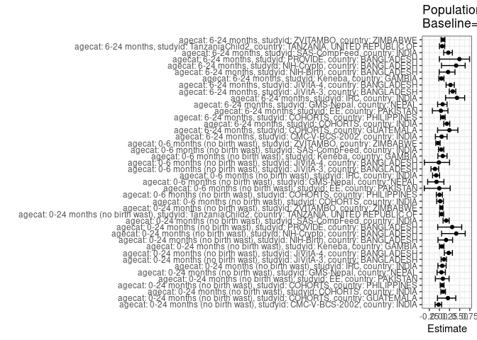

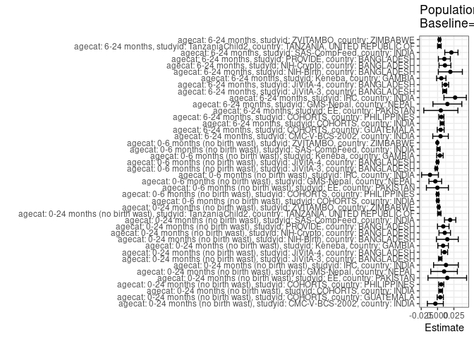

## Results Table

### Parameter: TSM

| agecat | studyid | country | intervention_level | baseline_level | estimate | ci_lower | ci_upper |
| --- | --- | --- | --- | --- | --- | --- | --- |
| 0-24 months (no birth wast) | CMC-V-BCS-2002 | INDIA | Normal or high birthweight | NA | 0.1557632 | 0.1160384 | 0.1954881 |
| 0-24 months (no birth wast) | CMC-V-BCS-2002 | INDIA | Low birthweight | NA | 0.1250000 | 0.0223688 | 0.2276312 |
| 0-24 months (no birth wast) | COHORTS | GUATEMALA | Normal or high birthweight | NA | 0.0155131 | 0.0071413 | 0.0238849 |
| 0-24 months (no birth wast) | COHORTS | GUATEMALA | Low birthweight | NA | 0.0632911 | 0.0095700 | 0.1170123 |
| 0-24 months (no birth wast) | COHORTS | INDIA | Normal or high birthweight | NA | 0.0458362 | 0.0402225 | 0.0514498 |
| 0-24 months (no birth wast) | COHORTS | INDIA | Low birthweight | NA | 0.0706859 | 0.0560713 | 0.0853006 |
| 0-24 months (no birth wast) | COHORTS | PHILIPPINES | Normal or high birthweight | NA | 0.0777518 | 0.0676502 | 0.0878534 |
| 0-24 months (no birth wast) | COHORTS | PHILIPPINES | Low birthweight | NA | 0.1351746 | 0.0948234 | 0.1755258 |
| 0-24 months (no birth wast) | EE | PAKISTAN | Normal or high birthweight | NA | 0.1606498 | 0.1139018 | 0.2073979 |
| 0-24 months (no birth wast) | EE | PAKISTAN | Low birthweight | NA | 0.1870262 | 0.1190982 | 0.2549541 |
| 0-24 months (no birth wast) | GMS-Nepal | NEPAL | Normal or high birthweight | NA | 0.1888035 | 0.1530233 | 0.2245837 |
| 0-24 months (no birth wast) | GMS-Nepal | NEPAL | Low birthweight | NA | 0.2274351 | 0.1653741 | 0.2894961 |
| 0-24 months (no birth wast) | IRC | INDIA | Normal or high birthweight | NA | 0.1732574 | 0.1326249 | 0.2138899 |
| 0-24 months (no birth wast) | IRC | INDIA | Low birthweight | NA | 0.2462874 | 0.1410488 | 0.3515260 |
| 0-24 months (no birth wast) | JiVitA-3 | BANGLADESH | Normal or high birthweight | NA | 0.0334645 | 0.0298469 | 0.0370821 |
| 0-24 months (no birth wast) | JiVitA-3 | BANGLADESH | Low birthweight | NA | 0.0430812 | 0.0382030 | 0.0479595 |
| 0-24 months (no birth wast) | JiVitA-4 | BANGLADESH | Normal or high birthweight | NA | 0.0358174 | 0.0289476 | 0.0426871 |
| 0-24 months (no birth wast) | JiVitA-4 | BANGLADESH | Low birthweight | NA | 0.0760469 | 0.0594943 | 0.0925996 |
| 0-24 months (no birth wast) | Keneba | GAMBIA | Normal or high birthweight | NA | 0.1389556 | 0.1201861 | 0.1577250 |
| 0-24 months (no birth wast) | Keneba | GAMBIA | Low birthweight | NA | 0.2066490 | 0.1517563 | 0.2615417 |
| 0-24 months (no birth wast) | NIH-Birth | BANGLADESH | Normal or high birthweight | NA | 0.0762855 | 0.0506031 | 0.1019679 |
| 0-24 months (no birth wast) | NIH-Birth | BANGLADESH | Low birthweight | NA | 0.1249421 | 0.0756512 | 0.1742329 |
| 0-24 months (no birth wast) | NIH-Crypto | BANGLADESH | Normal or high birthweight | NA | 0.0155440 | 0.0054613 | 0.0256267 |
| 0-24 months (no birth wast) | NIH-Crypto | BANGLADESH | Low birthweight | NA | 0.0628571 | 0.0268741 | 0.0988402 |
| 0-24 months (no birth wast) | PROVIDE | BANGLADESH | Normal or high birthweight | NA | 0.0189394 | 0.0073041 | 0.0305747 |
| 0-24 months (no birth wast) | PROVIDE | BANGLADESH | Low birthweight | NA | 0.0566038 | 0.0206590 | 0.0925485 |
| 0-24 months (no birth wast) | SAS-CompFeed | INDIA | Normal or high birthweight | NA | 0.0953483 | 0.0729147 | 0.1177820 |
| 0-24 months (no birth wast) | SAS-CompFeed | INDIA | Low birthweight | NA | 0.1723192 | 0.1300045 | 0.2146340 |
| 0-24 months (no birth wast) | TanzaniaChild2 | TANZANIA, UNITED REPUBLIC OF | Normal or high birthweight | NA | 0.0473657 | 0.0386395 | 0.0560920 |
| 0-24 months (no birth wast) | TanzaniaChild2 | TANZANIA, UNITED REPUBLIC OF | Low birthweight | NA | 0.1249623 | 0.0477813 | 0.2021433 |

[output cut: 54 more lines]

### Parameter: E(Y)

| agecat | studyid | country | intervention_level | baseline_level | estimate | ci_lower | ci_upper |
| --- | --- | --- | --- | --- | --- | --- | --- |
| 0-24 months (no birth wast) | CMC-V-BCS-2002 | INDIA | NA | NA | 0.1523546 | 0.1152325 | 0.1894766 |
| 0-24 months (no birth wast) | COHORTS | GUATEMALA | NA | NA | 0.0196292 | 0.0106457 | 0.0286128 |
| 0-24 months (no birth wast) | COHORTS | INDIA | NA | NA | 0.0505825 | 0.0452644 | 0.0559005 |
| 0-24 months (no birth wast) | COHORTS | PHILIPPINES | NA | NA | 0.0833613 | 0.0734265 | 0.0932961 |
| 0-24 months (no birth wast) | EE | PAKISTAN | NA | NA | 0.1755319 | 0.1370287 | 0.2140352 |
| 0-24 months (no birth wast) | GMS-Nepal | NEPAL | NA | NA | 0.1987860 | 0.1682929 | 0.2292792 |
| 0-24 months (no birth wast) | IRC | INDIA | NA | NA | 0.1861042 | 0.1480592 | 0.2241492 |
| 0-24 months (no birth wast) | JiVitA-3 | BANGLADESH | NA | NA | 0.0376119 | 0.0347245 | 0.0404993 |
| 0-24 months (no birth wast) | JiVitA-4 | BANGLADESH | NA | NA | 0.0463561 | 0.0396916 | 0.0530207 |
| 0-24 months (no birth wast) | Keneba | GAMBIA | NA | NA | 0.1474234 | 0.1296705 | 0.1651762 |
| 0-24 months (no birth wast) | NIH-Birth | BANGLADESH | NA | NA | 0.0912220 | 0.0677898 | 0.1146542 |
| 0-24 months (no birth wast) | NIH-Crypto | BANGLADESH | NA | NA | 0.0265252 | 0.0150478 | 0.0380026 |
| 0-24 months (no birth wast) | PROVIDE | BANGLADESH | NA | NA | 0.0276565 | 0.0153851 | 0.0399279 |
| 0-24 months (no birth wast) | SAS-CompFeed | INDIA | NA | NA | 0.1146113 | 0.0915227 | 0.1376999 |
| 0-24 months (no birth wast) | TanzaniaChild2 | TANZANIA, UNITED REPUBLIC OF | NA | NA | 0.0500212 | 0.0412227 | 0.0588197 |
| 0-24 months (no birth wast) | ZVITAMBO | ZIMBABWE | NA | NA | 0.0350916 | 0.0319981 | 0.0381851 |
| 0-6 months (no birth wast) | COHORTS | INDIA | NA | NA | 0.0194945 | 0.0160113 | 0.0229777 |
| 0-6 months (no birth wast) | COHORTS | PHILIPPINES | NA | NA | 0.0223426 | 0.0170120 | 0.0276732 |
| 0-6 months (no birth wast) | EE | PAKISTAN | NA | NA | 0.0534759 | 0.0306442 | 0.0763077 |
| 0-6 months (no birth wast) | GMS-Nepal | NEPAL | NA | NA | 0.0483619 | 0.0317414 | 0.0649825 |
| 0-6 months (no birth wast) | IRC | INDIA | NA | NA | 0.1458333 | 0.1104867 | 0.1811800 |
| 0-6 months (no birth wast) | JiVitA-3 | BANGLADESH | NA | NA | 0.0175574 | 0.0154912 | 0.0196236 |
| 0-6 months (no birth wast) | JiVitA-4 | BANGLADESH | NA | NA | 0.0048033 | 0.0020515 | 0.0075551 |
| 0-6 months (no birth wast) | Keneba | GAMBIA | NA | NA | 0.0434496 | 0.0331941 | 0.0537052 |
| 0-6 months (no birth wast) | SAS-CompFeed | INDIA | NA | NA | 0.0313993 | 0.0187576 | 0.0440411 |
| 0-6 months (no birth wast) | ZVITAMBO | ZIMBABWE | NA | NA | 0.0098995 | 0.0082190 | 0.0115800 |
| 6-24 months | CMC-V-BCS-2002 | INDIA | NA | NA | 0.0821918 | 0.0539763 | 0.1104073 |
| 6-24 months | COHORTS | GUATEMALA | NA | NA | 0.0193470 | 0.0099536 | 0.0287404 |
| 6-24 months | COHORTS | INDIA | NA | NA | 0.0381013 | 0.0333732 | 0.0428293 |
| 6-24 months | COHORTS | PHILIPPINES | NA | NA | 0.0676067 | 0.0582484 | 0.0769649 |
| 6-24 months | EE | PAKISTAN | NA | NA | 0.1367292 | 0.1018167 | 0.1716417 |
| 6-24 months | GMS-Nepal | NEPAL | NA | NA | 0.1901528 | 0.1584343 | 0.2218713 |
| 6-24 months | IRC | INDIA | NA | NA | 0.0618812 | 0.0383576 | 0.0854048 |
| 6-24 months | JiVitA-3 | BANGLADESH | NA | NA | 0.0331773 | 0.0301204 | 0.0362342 |
| 6-24 months | JiVitA-4 | BANGLADESH | NA | NA | 0.0442321 | 0.0375131 | 0.0509510 |
| 6-24 months | Keneba | GAMBIA | NA | NA | 0.1140530 | 0.0978143 | 0.1302917 |
| 6-24 months | NIH-Birth | BANGLADESH | NA | NA | 0.0919540 | 0.0671416 | 0.1167664 |
| 6-24 months | NIH-Crypto | BANGLADESH | NA | NA | 0.0273973 | 0.0155476 | 0.0392469 |
| 6-24 months | PROVIDE | BANGLADESH | NA | NA | 0.0211382 | 0.0097604 | 0.0325160 |
| 6-24 months | SAS-CompFeed | INDIA | NA | NA | 0.0964467 | 0.0724546 | 0.1204388 |
| 6-24 months | TanzaniaChild2 | TANZANIA, UNITED REPUBLIC OF | NA | NA | 0.0405405 | 0.0318905 | 0.0491906 |
| 6-24 months | ZVITAMBO | ZIMBABWE | NA | NA | 0.0329314 | 0.0295624 | 0.0363003 |

### Parameter: RR

| agecat | studyid | country | intervention_level | baseline_level | estimate | ci_lower | ci_upper |
| --- | --- | --- | --- | --- | --- | --- | --- |
| 0-24 months (no birth wast) | CMC-V-BCS-2002 | INDIA | Normal or high birthweight | Normal or high birthweight | 1.0000000 | 1.0000000 | 1.0000000 |
| 0-24 months (no birth wast) | CMC-V-BCS-2002 | INDIA | Low birthweight | Normal or high birthweight | 0.8025000 | 0.3396735 | 1.8959567 |
| 0-24 months (no birth wast) | COHORTS | GUATEMALA | Normal or high birthweight | Normal or high birthweight | 1.0000000 | 1.0000000 | 1.0000000 |
| 0-24 months (no birth wast) | COHORTS | GUATEMALA | Low birthweight | Normal or high birthweight | 4.0798442 | 1.4921752 | 11.1549428 |
| 0-24 months (no birth wast) | COHORTS | INDIA | Normal or high birthweight | Normal or high birthweight | 1.0000000 | 1.0000000 | 1.0000000 |
| 0-24 months (no birth wast) | COHORTS | INDIA | Low birthweight | Normal or high birthweight | 1.5421421 | 1.2130854 | 1.9604572 |
| 0-24 months (no birth wast) | COHORTS | PHILIPPINES | Normal or high birthweight | Normal or high birthweight | 1.0000000 | 1.0000000 | 1.0000000 |
| 0-24 months (no birth wast) | COHORTS | PHILIPPINES | Low birthweight | Normal or high birthweight | 1.7385399 | 1.2556948 | 2.4070507 |
| 0-24 months (no birth wast) | EE | PAKISTAN | Normal or high birthweight | Normal or high birthweight | 1.0000000 | 1.0000000 | 1.0000000 |
| 0-24 months (no birth wast) | EE | PAKISTAN | Low birthweight | Normal or high birthweight | 1.1641852 | 0.7294734 | 1.8579529 |
| 0-24 months (no birth wast) | GMS-Nepal | NEPAL | Normal or high birthweight | Normal or high birthweight | 1.0000000 | 1.0000000 | 1.0000000 |
| 0-24 months (no birth wast) | GMS-Nepal | NEPAL | Low birthweight | Normal or high birthweight | 1.2046128 | 0.8645558 | 1.6784250 |
| 0-24 months (no birth wast) | IRC | INDIA | Normal or high birthweight | Normal or high birthweight | 1.0000000 | 1.0000000 | 1.0000000 |
| 0-24 months (no birth wast) | IRC | INDIA | Low birthweight | Normal or high birthweight | 1.4215114 | 0.8729173 | 2.3148752 |
| 0-24 months (no birth wast) | JiVitA-3 | BANGLADESH | Normal or high birthweight | Normal or high birthweight | 1.0000000 | 1.0000000 | 1.0000000 |
| 0-24 months (no birth wast) | JiVitA-3 | BANGLADESH | Low birthweight | Normal or high birthweight | 1.2873705 | 1.1031674 | 1.5023312 |
| 0-24 months (no birth wast) | JiVitA-4 | BANGLADESH | Normal or high birthweight | Normal or high birthweight | 1.0000000 | 1.0000000 | 1.0000000 |
| 0-24 months (no birth wast) | JiVitA-4 | BANGLADESH | Low birthweight | Normal or high birthweight | 2.1231873 | 1.5818911 | 2.8497059 |
| 0-24 months (no birth wast) | Keneba | GAMBIA | Normal or high birthweight | Normal or high birthweight | 1.0000000 | 1.0000000 | 1.0000000 |
| 0-24 months (no birth wast) | Keneba | GAMBIA | Low birthweight | Normal or high birthweight | 1.4871590 | 1.1043911 | 2.0025893 |
| 0-24 months (no birth wast) | NIH-Birth | BANGLADESH | Normal or high birthweight | Normal or high birthweight | 1.0000000 | 1.0000000 | 1.0000000 |
| 0-24 months (no birth wast) | NIH-Birth | BANGLADESH | Low birthweight | Normal or high birthweight | 1.6378216 | 0.9764174 | 2.7472467 |
| 0-24 months (no birth wast) | NIH-Crypto | BANGLADESH | Normal or high birthweight | Normal or high birthweight | 1.0000000 | 1.0000000 | 1.0000000 |
| 0-24 months (no birth wast) | NIH-Crypto | BANGLADESH | Low birthweight | Normal or high birthweight | 4.0438095 | 1.7024219 | 9.6053718 |
| 0-24 months (no birth wast) | PROVIDE | BANGLADESH | Normal or high birthweight | Normal or high birthweight | 1.0000000 | 1.0000000 | 1.0000000 |
| 0-24 months (no birth wast) | PROVIDE | BANGLADESH | Low birthweight | Normal or high birthweight | 2.9886792 | 1.2352498 | 7.2310911 |
| 0-24 months (no birth wast) | SAS-CompFeed | INDIA | Normal or high birthweight | Normal or high birthweight | 1.0000000 | 1.0000000 | 1.0000000 |
| 0-24 months (no birth wast) | SAS-CompFeed | INDIA | Low birthweight | Normal or high birthweight | 1.8072599 | 1.3895501 | 2.3505366 |
| 0-24 months (no birth wast) | TanzaniaChild2 | TANZANIA, UNITED REPUBLIC OF | Normal or high birthweight | Normal or high birthweight | 1.0000000 | 1.0000000 | 1.0000000 |
| 0-24 months (no birth wast) | TanzaniaChild2 | TANZANIA, UNITED REPUBLIC OF | Low birthweight | Normal or high birthweight | 2.6382430 | 1.3848600 | 5.0260141 |

[output cut: 54 more lines]

### Parameter: PAR

| agecat | studyid | country | intervention_level | baseline_level | estimate | ci_lower | ci_upper |
| --- | --- | --- | --- | --- | --- | --- | --- |
| 0-24 months (no birth wast) | CMC-V-BCS-2002 | INDIA | Normal or high birthweight | NA | -0.0034087 | -0.0156434 | 0.0088261 |
| 0-24 months (no birth wast) | COHORTS | GUATEMALA | Normal or high birthweight | NA | 0.0041161 | -0.0006476 | 0.0088798 |
| 0-24 months (no birth wast) | COHORTS | INDIA | Normal or high birthweight | NA | 0.0047463 | 0.0018494 | 0.0076431 |
| 0-24 months (no birth wast) | COHORTS | PHILIPPINES | Normal or high birthweight | NA | 0.0056095 | 0.0016811 | 0.0095380 |
| 0-24 months (no birth wast) | EE | PAKISTAN | Normal or high birthweight | NA | 0.0148821 | -0.0146848 | 0.0444489 |
| 0-24 months (no birth wast) | GMS-Nepal | NEPAL | Normal or high birthweight | NA | 0.0099826 | -0.0103502 | 0.0303154 |
| 0-24 months (no birth wast) | IRC | INDIA | Normal or high birthweight | NA | 0.0128468 | -0.0060887 | 0.0317823 |
| 0-24 months (no birth wast) | JiVitA-3 | BANGLADESH | Normal or high birthweight | NA | 0.0041474 | 0.0016288 | 0.0066660 |
| 0-24 months (no birth wast) | JiVitA-4 | BANGLADESH | Normal or high birthweight | NA | 0.0105388 | 0.0057159 | 0.0153617 |
| 0-24 months (no birth wast) | Keneba | GAMBIA | Normal or high birthweight | NA | 0.0084678 | 0.0004015 | 0.0165340 |
| 0-24 months (no birth wast) | NIH-Birth | BANGLADESH | Normal or high birthweight | NA | 0.0149365 | -0.0018138 | 0.0316868 |
| 0-24 months (no birth wast) | NIH-Crypto | BANGLADESH | Normal or high birthweight | NA | 0.0109812 | 0.0021914 | 0.0197709 |
| 0-24 months (no birth wast) | PROVIDE | BANGLADESH | Normal or high birthweight | NA | 0.0087171 | -0.0001074 | 0.0175416 |
| 0-24 months (no birth wast) | SAS-CompFeed | INDIA | Normal or high birthweight | NA | 0.0192629 | 0.0105835 | 0.0279423 |
| 0-24 months (no birth wast) | TanzaniaChild2 | TANZANIA, UNITED REPUBLIC OF | Normal or high birthweight | NA | 0.0026555 | 0.0001144 | 0.0051965 |
| 0-24 months (no birth wast) | ZVITAMBO | ZIMBABWE | Normal or high birthweight | NA | 0.0016689 | 0.0003540 | 0.0029838 |
| 0-6 months (no birth wast) | COHORTS | INDIA | Normal or high birthweight | NA | 0.0003604 | -0.0012367 | 0.0019575 |
| 0-6 months (no birth wast) | COHORTS | PHILIPPINES | Normal or high birthweight | NA | 0.0000460 | -0.0016358 | 0.0017279 |
| 0-6 months (no birth wast) | EE | PAKISTAN | Normal or high birthweight | NA | -0.0002431 | -0.0170753 | 0.0165891 |
| 0-6 months (no birth wast) | GMS-Nepal | NEPAL | Normal or high birthweight | NA | -0.0034739 | -0.0132029 | 0.0062550 |
| 0-6 months (no birth wast) | IRC | INDIA | Normal or high birthweight | NA | -0.0115741 | -0.0244373 | 0.0012891 |
| 0-6 months (no birth wast) | JiVitA-3 | BANGLADESH | Normal or high birthweight | NA | -0.0019385 | -0.0036240 | -0.0002529 |
| 0-6 months (no birth wast) | JiVitA-4 | BANGLADESH | Normal or high birthweight | NA | -0.0000658 | -0.0015406 | 0.0014089 |
| 0-6 months (no birth wast) | Keneba | GAMBIA | Normal or high birthweight | NA | 0.0035446 | -0.0014151 | 0.0085043 |
| 0-6 months (no birth wast) | SAS-CompFeed | INDIA | Normal or high birthweight | NA | 0.0014041 | -0.0009910 | 0.0037992 |
| 0-6 months (no birth wast) | ZVITAMBO | ZIMBABWE | Normal or high birthweight | NA | -0.0003472 | -0.0008769 | 0.0001825 |
| 6-24 months | CMC-V-BCS-2002 | INDIA | Normal or high birthweight | NA | 0.0045520 | -0.0073343 | 0.0164384 |
| 6-24 months | COHORTS | GUATEMALA | Normal or high birthweight | NA | 0.0047582 | -0.0005192 | 0.0100356 |
| 6-24 months | COHORTS | INDIA | Normal or high birthweight | NA | 0.0070018 | 0.0040573 | 0.0099462 |
| 6-24 months | COHORTS | PHILIPPINES | Normal or high birthweight | NA | 0.0057938 | 0.0018897 | 0.0096978 |
| 6-24 months | EE | PAKISTAN | Normal or high birthweight | NA | 0.0050099 | -0.0211056 | 0.0311255 |
| 6-24 months | GMS-Nepal | NEPAL | Normal or high birthweight | NA | 0.0150356 | -0.0070796 | 0.0371509 |
| 6-24 months | IRC | INDIA | Normal or high birthweight | NA | 0.0268771 | 0.0097476 | 0.0440065 |
| 6-24 months | JiVitA-3 | BANGLADESH | Normal or high birthweight | NA | 0.0108815 | 0.0079700 | 0.0137930 |
| 6-24 months | JiVitA-4 | BANGLADESH | Normal or high birthweight | NA | 0.0120812 | 0.0072418 | 0.0169205 |
| 6-24 months | Keneba | GAMBIA | Normal or high birthweight | NA | 0.0057150 | -0.0014698 | 0.0128998 |
| 6-24 months | NIH-Birth | BANGLADESH | Normal or high birthweight | NA | 0.0195853 | 0.0011934 | 0.0379771 |
| 6-24 months | NIH-Crypto | BANGLADESH | Normal or high birthweight | NA | 0.0112971 | 0.0022155 | 0.0203787 |
| 6-24 months | PROVIDE | BANGLADESH | Normal or high birthweight | NA | 0.0104316 | 0.0012562 | 0.0196070 |
| 6-24 months | SAS-CompFeed | INDIA | Normal or high birthweight | NA | 0.0211403 | 0.0110087 | 0.0312719 |
| 6-24 months | TanzaniaChild2 | TANZANIA, UNITED REPUBLIC OF | Normal or high birthweight | NA | 0.0027754 | 0.0000789 | 0.0054719 |
| 6-24 months | ZVITAMBO | ZIMBABWE | Normal or high birthweight | NA | 0.0029460 | 0.0013646 | 0.0045273 |

### Parameter: PAF

| agecat | studyid | country | intervention_level | baseline_level | estimate | ci_lower | ci_upper |
| --- | --- | --- | --- | --- | --- | --- | --- |
| 0-24 months (no birth wast) | CMC-V-BCS-2002 | INDIA | Normal or high birthweight | NA | -0.0223733 | -0.1057891 | 0.0547501 |
| 0-24 months (no birth wast) | COHORTS | GUATEMALA | Normal or high birthweight | NA | 0.2096924 | -0.0486896 | 0.4044128 |
| 0-24 months (no birth wast) | COHORTS | INDIA | Normal or high birthweight | NA | 0.0938325 | 0.0355750 | 0.1485709 |
| 0-24 months (no birth wast) | COHORTS | PHILIPPINES | Normal or high birthweight | NA | 0.0672920 | 0.0195473 | 0.1127116 |
| 0-24 months (no birth wast) | EE | PAKISTAN | Normal or high birthweight | NA | 0.0847827 | -0.0997071 | 0.2383220 |
| 0-24 months (no birth wast) | GMS-Nepal | NEPAL | Normal or high birthweight | NA | 0.0502177 | -0.0576649 | 0.1470962 |
| 0-24 months (no birth wast) | IRC | INDIA | Normal or high birthweight | NA | 0.0690301 | -0.0378821 | 0.1649294 |
| 0-24 months (no birth wast) | JiVitA-3 | BANGLADESH | Normal or high birthweight | NA | 0.1102679 | 0.0411448 | 0.1744080 |
| 0-24 months (no birth wast) | JiVitA-4 | BANGLADESH | Normal or high birthweight | NA | 0.2273440 | 0.1221557 | 0.3199280 |
| 0-24 months (no birth wast) | Keneba | GAMBIA | Normal or high birthweight | NA | 0.0574385 | 0.0013566 | 0.1103709 |
| 0-24 months (no birth wast) | NIH-Birth | BANGLADESH | Normal or high birthweight | NA | 0.1637381 | -0.0362036 | 0.3250999 |
| 0-24 months (no birth wast) | NIH-Crypto | BANGLADESH | Normal or high birthweight | NA | 0.4139896 | 0.0540478 | 0.6369709 |
| 0-24 months (no birth wast) | PROVIDE | BANGLADESH | Normal or high birthweight | NA | 0.3151914 | -0.0430123 | 0.5503765 |
| 0-24 months (no birth wast) | SAS-CompFeed | INDIA | Normal or high birthweight | NA | 0.1680718 | 0.0902394 | 0.2392454 |
| 0-24 months (no birth wast) | TanzaniaChild2 | TANZANIA, UNITED REPUBLIC OF | Normal or high birthweight | NA | 0.0530868 | 0.0017027 | 0.1018261 |
| 0-24 months (no birth wast) | ZVITAMBO | ZIMBABWE | Normal or high birthweight | NA | 0.0475579 | 0.0095709 | 0.0840879 |
| 0-6 months (no birth wast) | COHORTS | INDIA | Normal or high birthweight | NA | 0.0184867 | -0.0669023 | 0.0970417 |
| 0-6 months (no birth wast) | COHORTS | PHILIPPINES | Normal or high birthweight | NA | 0.0020607 | -0.0761268 | 0.0745675 |
| 0-6 months (no birth wast) | EE | PAKISTAN | Normal or high birthweight | NA | -0.0045455 | -0.3741944 | 0.2656704 |
| 0-6 months (no birth wast) | GMS-Nepal | NEPAL | Normal or high birthweight | NA | -0.0718317 | -0.2914856 | 0.1104638 |
| 0-6 months (no birth wast) | IRC | INDIA | Normal or high birthweight | NA | -0.0793651 | -0.1698267 | 0.0041013 |
| 0-6 months (no birth wast) | JiVitA-3 | BANGLADESH | Normal or high birthweight | NA | -0.1104070 | -0.2089261 | -0.0199166 |
| 0-6 months (no birth wast) | JiVitA-4 | BANGLADESH | Normal or high birthweight | NA | -0.0137090 | -0.3709271 | 0.2504300 |
| 0-6 months (no birth wast) | Keneba | GAMBIA | Normal or high birthweight | NA | 0.0815794 | -0.0384803 | 0.1877589 |
| 0-6 months (no birth wast) | SAS-CompFeed | INDIA | Normal or high birthweight | NA | 0.0447177 | -0.0232547 | 0.1081748 |
| 0-6 months (no birth wast) | ZVITAMBO | ZIMBABWE | Normal or high birthweight | NA | -0.0350742 | -0.0896120 | 0.0167339 |
| 6-24 months | CMC-V-BCS-2002 | INDIA | Normal or high birthweight | NA | 0.0553830 | -0.0996776 | 0.1885792 |
| 6-24 months | COHORTS | GUATEMALA | Normal or high birthweight | NA | 0.2459383 | -0.0450901 | 0.4559235 |
| 6-24 months | COHORTS | INDIA | Normal or high birthweight | NA | 0.1837677 | 0.1062461 | 0.2545653 |
| 6-24 months | COHORTS | PHILIPPINES | Normal or high birthweight | NA | 0.0856981 | 0.0272178 | 0.1406629 |
| 6-24 months | EE | PAKISTAN | Normal or high birthweight | NA | 0.0366414 | -0.1744939 | 0.2098215 |
| 6-24 months | GMS-Nepal | NEPAL | Normal or high birthweight | NA | 0.0790713 | -0.0444998 | 0.1880232 |
| 6-24 months | IRC | INDIA | Normal or high birthweight | NA | 0.4343334 | 0.1517296 | 0.6227870 |
| 6-24 months | JiVitA-3 | BANGLADESH | Normal or high birthweight | NA | 0.3279787 | 0.2426953 | 0.4036581 |
| 6-24 months | JiVitA-4 | BANGLADESH | Normal or high birthweight | NA | 0.2731313 | 0.1648799 | 0.3673508 |
| 6-24 months | Keneba | GAMBIA | Normal or high birthweight | NA | 0.0501081 | -0.0147346 | 0.1108073 |
| 6-24 months | NIH-Birth | BANGLADESH | Normal or high birthweight | NA | 0.2129898 | -0.0046307 | 0.3834699 |
| 6-24 months | NIH-Crypto | BANGLADESH | Normal or high birthweight | NA | 0.4123435 | 0.0515703 | 0.6358821 |
| 6-24 months | PROVIDE | BANGLADESH | Normal or high birthweight | NA | 0.4934937 | -0.0019911 | 0.7439611 |
| 6-24 months | SAS-CompFeed | INDIA | Normal or high birthweight | NA | 0.2191914 | 0.1044211 | 0.3192538 |
| 6-24 months | TanzaniaChild2 | TANZANIA, UNITED REPUBLIC OF | Normal or high birthweight | NA | 0.0684601 | 0.0011170 | 0.1312630 |
| 6-24 months | ZVITAMBO | ZIMBABWE | Normal or high birthweight | NA | 0.0894575 | 0.0410004 | 0.1354661 |